# Risk Factor Analysis

## Outcome Variable

**Outcome Variable:** stunted

## Predictor Variables

**Intervention Variable:** exclfeed3

**Adjustment Set:**

- arm
- sex
- brthmon
- W_mage
- meducyrs
- feducyrs
- hhwealth_quart
- hfoodsec
- W_mhtcm
- W_mwtkg
- W_mbmi
- vagbrth
- W_gagebrth
- W_birthwt
- W_birthlen
- W_nrooms
- W_nchldlt5
- month
- W_parity
- impfloor
- impsan
- safeh20
- delta_W_mage
- delta_meducyrs
- delta_feducyrs
- delta_hhwealth_quart
- delta_hfoodsec
- delta_W_mhtcm
- delta_W_mwtkg
- delta_W_mbmi
- delta_vagbrth
- delta_W_gagebrth
- delta_W_birthwt
- delta_W_birthlen
- delta_W_nrooms
- delta_W_nchldlt5
- delta_month
- delta_W_parity
- delta_impfloor
- delta_impsan
- delta_safeh20

## Stratifying Variables

The analysis was stratified on these variable(s):

- agecat
- studyid
- country

## Data Summary

| agecat | studyid | country | exclfeed3 | stunted | n_cell | n |
| --- | --- | --- | --- | --- | --- | --- |
| Birth | ki0047075b-MAL-ED | BANGLADESH | 1 | 0 | 112 | 215 |
| Birth | ki0047075b-MAL-ED | BANGLADESH | 1 | 1 | 26 | 215 |
| Birth | ki0047075b-MAL-ED | BANGLADESH | 0 | 0 | 63 | 215 |
| Birth | ki0047075b-MAL-ED | BANGLADESH | 0 | 1 | 14 | 215 |
| Birth | ki0047075b-MAL-ED | BRAZIL | 1 | 0 | 10 | 57 |
| Birth | ki0047075b-MAL-ED | BRAZIL | 1 | 1 | 2 | 57 |
| Birth | ki0047075b-MAL-ED | BRAZIL | 0 | 0 | 39 | 57 |
| Birth | ki0047075b-MAL-ED | BRAZIL | 0 | 1 | 6 | 57 |
| Birth | ki0047075b-MAL-ED | INDIA | 1 | 0 | 16 | 41 |
| Birth | ki0047075b-MAL-ED | INDIA | 1 | 1 | 8 | 41 |
| Birth | ki0047075b-MAL-ED | INDIA | 0 | 0 | 17 | 41 |
| Birth | ki0047075b-MAL-ED | INDIA | 0 | 1 | 0 | 41 |
| Birth | ki0047075b-MAL-ED | NEPAL | 1 | 0 | 8 | 26 |
| Birth | ki0047075b-MAL-ED | NEPAL | 1 | 1 | 0 | 26 |
| Birth | ki0047075b-MAL-ED | NEPAL | 0 | 0 | 16 | 26 |
| Birth | ki0047075b-MAL-ED | NEPAL | 0 | 1 | 2 | 26 |
| Birth | ki0047075b-MAL-ED | PERU | 1 | 0 | 41 | 223 |
| Birth | ki0047075b-MAL-ED | PERU | 1 | 1 | 8 | 223 |
| Birth | ki0047075b-MAL-ED | PERU | 0 | 0 | 158 | 223 |
| Birth | ki0047075b-MAL-ED | PERU | 0 | 1 | 16 | 223 |
| Birth | ki0047075b-MAL-ED | SOUTH AFRICA | 1 | 0 | 12 | 100 |
| Birth | ki0047075b-MAL-ED | SOUTH AFRICA | 1 | 1 | 0 | 100 |
| Birth | ki0047075b-MAL-ED | SOUTH AFRICA | 0 | 0 | 79 | 100 |
| Birth | ki0047075b-MAL-ED | SOUTH AFRICA | 0 | 1 | 9 | 100 |
| Birth | ki0047075b-MAL-ED | TANZANIA, UNITED REPUBLIC OF | 1 | 0 | 14 | 102 |
| Birth | ki0047075b-MAL-ED | TANZANIA, UNITED REPUBLIC OF | 1 | 1 | 3 | 102 |
| Birth | ki0047075b-MAL-ED | TANZANIA, UNITED REPUBLIC OF | 0 | 0 | 69 | 102 |
| Birth | ki0047075b-MAL-ED | TANZANIA, UNITED REPUBLIC OF | 0 | 1 | 16 | 102 |
| Birth | ki1000108-CMC-V-BCS-2002 | INDIA | 1 | 0 | 4 | 4 |
| Birth | ki1000108-CMC-V-BCS-2002 | INDIA | 1 | 1 | 0 | 4 |

[output cut: 158 more lines]

The following strata were considered:

- agecat: 24 months, studyid: ki0047075b-MAL-ED, country: BANGLADESH
- agecat: 24 months, studyid: ki0047075b-MAL-ED, country: BRAZIL
- agecat: 24 months, studyid: ki0047075b-MAL-ED, country: INDIA
- agecat: 24 months, studyid: ki0047075b-MAL-ED, country: NEPAL
- agecat: 24 months, studyid: ki0047075b-MAL-ED, country: PERU
- agecat: 24 months, studyid: ki0047075b-MAL-ED, country: SOUTH AFRICA
- agecat: 24 months, studyid: ki0047075b-MAL-ED, country: TANZANIA, UNITED REPUBLIC OF
- agecat: 24 months, studyid: ki1000108-CMC-V-BCS-2002, country: INDIA
- agecat: 24 months, studyid: ki1000108-IRC, country: INDIA
- agecat: 24 months, studyid: ki1000109-EE, country: PAKISTAN
- agecat: 24 months, studyid: ki1017093b-PROVIDE, country: BANGLADESH
- agecat: 24 months, studyid: ki1101329-Keneba, country: GAMBIA
- agecat: 24 months, studyid: ki1113344-GMS-Nepal, country: NEPAL
- agecat: 24 months, studyid: kiGH5241-JiVitA-3, country: BANGLADESH
- agecat: 24 months, studyid: kiGH5241-JiVitA-4, country: BANGLADESH
- agecat: 6 months, studyid: ki0047075b-MAL-ED, country: BANGLADESH
- agecat: 6 months, studyid: ki0047075b-MAL-ED, country: BRAZIL
- agecat: 6 months, studyid: ki0047075b-MAL-ED, country: INDIA
- agecat: 6 months, studyid: ki0047075b-MAL-ED, country: NEPAL
- agecat: 6 months, studyid: ki0047075b-MAL-ED, country: PERU
- agecat: 6 months, studyid: ki0047075b-MAL-ED, country: SOUTH AFRICA
- agecat: 6 months, studyid: ki0047075b-MAL-ED, country: TANZANIA, UNITED REPUBLIC OF
- agecat: 6 months, studyid: ki1000108-CMC-V-BCS-2002, country: INDIA
- agecat: 6 months, studyid: ki1000108-IRC, country: INDIA
- agecat: 6 months, studyid: ki1000109-EE, country: PAKISTAN
- agecat: 6 months, studyid: ki1000304b-SAS-CompFeed, country: INDIA
- agecat: 6 months, studyid: ki1017093b-PROVIDE, country: BANGLADESH
- agecat: 6 months, studyid: ki1101329-Keneba, country: GAMBIA
- agecat: 6 months, studyid: ki1113344-GMS-Nepal, country: NEPAL
- agecat: 6 months, studyid: kiGH5241-JiVitA-3, country: BANGLADESH
- agecat: 6 months, studyid: kiGH5241-JiVitA-4, country: BANGLADESH
- agecat: Birth, studyid: ki0047075b-MAL-ED, country: BANGLADESH
- agecat: Birth, studyid: ki0047075b-MAL-ED, country: BRAZIL
- agecat: Birth, studyid: ki0047075b-MAL-ED, country: INDIA
- agecat: Birth, studyid: ki0047075b-MAL-ED, country: NEPAL
- agecat: Birth, studyid: ki0047075b-MAL-ED, country: PERU
- agecat: Birth, studyid: ki0047075b-MAL-ED, country: SOUTH AFRICA
- agecat: Birth, studyid: ki0047075b-MAL-ED, country: TANZANIA, UNITED REPUBLIC OF
- agecat: Birth, studyid: ki1000108-CMC-V-BCS-2002, country: INDIA
- agecat: Birth, studyid: ki1000108-IRC, country: INDIA
- agecat: Birth, studyid: ki1000109-EE, country: PAKISTAN
- agecat: Birth, studyid: ki1000304b-SAS-CompFeed, country: INDIA
- agecat: Birth, studyid: ki1017093b-PROVIDE, country: BANGLADESH
- agecat: Birth, studyid: ki1101329-Keneba, country: GAMBIA
- agecat: Birth, studyid: ki1113344-GMS-Nepal, country: NEPAL
- agecat: Birth, studyid: kiGH5241-JiVitA-3, country: BANGLADESH
- agecat: Birth, studyid: kiGH5241-JiVitA-4, country: BANGLADESH

### Dropped Strata

Some strata were dropped due to rare outcomes:

- agecat: Birth, studyid: ki0047075b-MAL-ED, country: BRAZIL
- agecat: Birth, studyid: ki0047075b-MAL-ED, country: INDIA
- agecat: Birth, studyid: ki0047075b-MAL-ED, country: NEPAL
- agecat: Birth, studyid: ki0047075b-MAL-ED, country: SOUTH AFRICA
- agecat: Birth, studyid: ki0047075b-MAL-ED, country: TANZANIA, UNITED REPUBLIC OF
- agecat: Birth, studyid: ki1000108-CMC-V-BCS-2002, country: INDIA
- agecat: Birth, studyid: ki1000108-IRC, country: INDIA
- agecat: Birth, studyid: ki1000109-EE, country: PAKISTAN
- agecat: Birth, studyid: kiGH5241-JiVitA-4, country: BANGLADESH
- agecat: 6 months, studyid: ki0047075b-MAL-ED, country: BRAZIL
- agecat: 6 months, studyid: ki0047075b-MAL-ED, country: NEPAL
- agecat: 6 months, studyid: ki0047075b-MAL-ED, country: SOUTH AFRICA
- agecat: 6 months, studyid: ki1000108-CMC-V-BCS-2002, country: INDIA
- agecat: 6 months, studyid: ki1000108-IRC, country: INDIA
- agecat: 6 months, studyid: ki1000109-EE, country: PAKISTAN
- agecat: 6 months, studyid: kiGH5241-JiVitA-4, country: BANGLADESH
- agecat: 24 months, studyid: ki0047075b-MAL-ED, country: BRAZIL
- agecat: 24 months, studyid: ki1000108-CMC-V-BCS-2002, country: INDIA
- agecat: 24 months, studyid: ki1000108-IRC, country: INDIA
- agecat: 24 months, studyid: ki1000109-EE, country: PAKISTAN

## Methods Detail

We’re interested in the causal parameters $E[Y_a]$ for all values of $a \in \mathcal{A}$. These parameters represent the mean outcome if, possibly contrary to fact, we intervened to set all units to have $A=a$. Under the randomization and positivity assumptions, these are identified by the statistical parameters $\psi_a=E_W[E_{Y|A,W}(Y|A=a,W)]$. In addition, we’re interested in the mean of $Y$, $E[Y]$ under no intervention (the observed mean). We will estimate these parameters by using SuperLearner to fit the relevant likelihood factors – $E_{Y|A,W}(Y|A=a,W)$ and $p(A=a|W)$, and then updating our likelihood fit using a joint TMLE.

For unadjusted analyses ($W=\{\}$), initial likelihoods were estimated using Lrnr_glm to estimate the simple $E(Y|A)$ and Lrnr_mean to estimate $p(A)$. For adjusted analyses, a small library containing Lrnr_glmnet, Lrnr_xgboost, and Lrnr_mean was used.

Having estimated these parameters, we will then use the delta method to estimate relative risks and attributable risks relative to a prespecified baseline level of $A$.

# Results Detail

## Results Plots

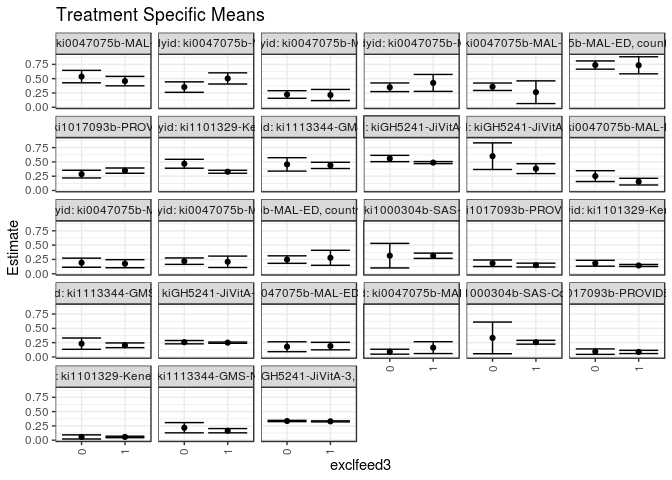

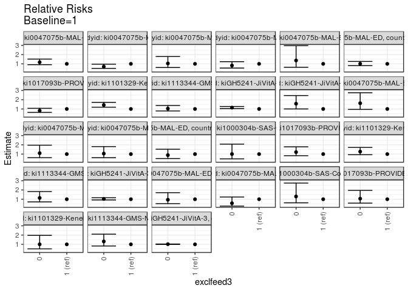

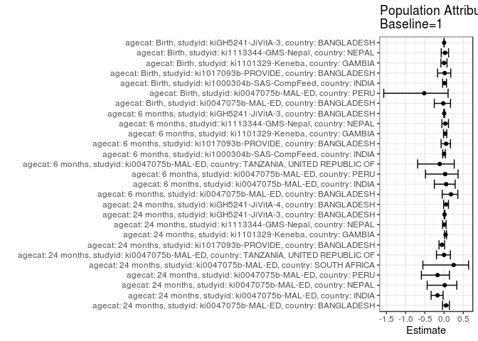

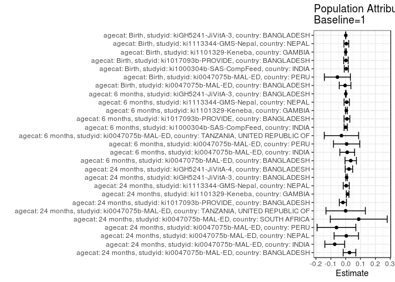

## Results Table

### Parameter: TSM

| agecat | studyid | country | intervention_level | baseline_level | estimate | ci_lower | ci_upper |
| --- | --- | --- | --- | --- | --- | --- | --- |
| Birth | ki0047075b-MAL-ED | BANGLADESH | 1 | NA | 0.1900766 | 0.1243847 | 0.2557685 |
| Birth | ki0047075b-MAL-ED | BANGLADESH | 0 | NA | 0.1791358 | 0.0927300 | 0.2655416 |
| Birth | ki0047075b-MAL-ED | PERU | 1 | NA | 0.1632653 | 0.0595443 | 0.2669863 |
| Birth | ki0047075b-MAL-ED | PERU | 0 | NA | 0.0919540 | 0.0489223 | 0.1349857 |
| Birth | ki1000304b-SAS-CompFeed | INDIA | 1 | NA | 0.2572254 | 0.2236819 | 0.2907690 |
| Birth | ki1000304b-SAS-CompFeed | INDIA | 0 | NA | 0.3333333 | 0.0564891 | 0.6101775 |
| Birth | ki1017093b-PROVIDE | BANGLADESH | 1 | NA | 0.0875285 | 0.0592330 | 0.1158239 |
| Birth | ki1017093b-PROVIDE | BANGLADESH | 0 | NA | 0.0930720 | 0.0449539 | 0.1411902 |
| Birth | ki1101329-Keneba | GAMBIA | 1 | NA | 0.0567613 | 0.0436539 | 0.0698687 |
| Birth | ki1101329-Keneba | GAMBIA | 0 | NA | 0.0569620 | 0.0208096 | 0.0931144 |
| Birth | ki1113344-GMS-Nepal | NEPAL | 1 | NA | 0.1659212 | 0.1285318 | 0.2033107 |
| Birth | ki1113344-GMS-Nepal | NEPAL | 0 | NA | 0.2180286 | 0.1286224 | 0.3074348 |
| Birth | kiGH5241-JiVitA-3 | BANGLADESH | 1 | NA | 0.3294906 | 0.3203263 | 0.3386549 |
| Birth | kiGH5241-JiVitA-3 | BANGLADESH | 0 | NA | 0.3352357 | 0.3244676 | 0.3460039 |
| 6 months | ki0047075b-MAL-ED | BANGLADESH | 1 | NA | 0.1550436 | 0.0968565 | 0.2132307 |
| 6 months | ki0047075b-MAL-ED | BANGLADESH | 0 | NA | 0.2513920 | 0.1568948 | 0.3458892 |
| 6 months | ki0047075b-MAL-ED | INDIA | 1 | NA | 0.1752760 | 0.1046700 | 0.2458820 |
| 6 months | ki0047075b-MAL-ED | INDIA | 0 | NA | 0.1927479 | 0.1129315 | 0.2725643 |
| 6 months | ki0047075b-MAL-ED | PERU | 1 | NA | 0.2085609 | 0.1091257 | 0.3079961 |
| 6 months | ki0047075b-MAL-ED | PERU | 0 | NA | 0.2197554 | 0.1634660 | 0.2760447 |
| 6 months | ki0047075b-MAL-ED | TANZANIA, UNITED REPUBLIC OF | 1 | NA | 0.2785120 | 0.1473447 | 0.4096794 |
| 6 months | ki0047075b-MAL-ED | TANZANIA, UNITED REPUBLIC OF | 0 | NA | 0.2473709 | 0.1817072 | 0.3130345 |
| 6 months | ki1000304b-SAS-CompFeed | INDIA | 1 | NA | 0.3139842 | 0.2679102 | 0.3600581 |
| 6 months | ki1000304b-SAS-CompFeed | INDIA | 0 | NA | 0.3157895 | 0.1014523 | 0.5301266 |
| 6 months | ki1017093b-PROVIDE | BANGLADESH | 1 | NA | 0.1505106 | 0.1166546 | 0.1843667 |
| 6 months | ki1017093b-PROVIDE | BANGLADESH | 0 | NA | 0.1828958 | 0.1258633 | 0.2399284 |
| 6 months | ki1101329-Keneba | GAMBIA | 1 | NA | 0.1443964 | 0.1268304 | 0.1619623 |
| 6 months | ki1101329-Keneba | GAMBIA | 0 | NA | 0.1832545 | 0.1315699 | 0.2349390 |
| 6 months | ki1113344-GMS-Nepal | NEPAL | 1 | NA | 0.2038596 | 0.1625360 | 0.2451833 |
| 6 months | ki1113344-GMS-Nepal | NEPAL | 0 | NA | 0.2326091 | 0.1337362 | 0.3314819 |
| 6 months | kiGH5241-JiVitA-3 | BANGLADESH | 1 | NA | 0.2500884 | 0.2392940 | 0.2608828 |
| 6 months | kiGH5241-JiVitA-3 | BANGLADESH | 0 | NA | 0.2585040 | 0.2298486 | 0.2871594 |
| 24 months | ki0047075b-MAL-ED | BANGLADESH | 1 | NA | 0.4573314 | 0.3748056 | 0.5398573 |
| 24 months | ki0047075b-MAL-ED | BANGLADESH | 0 | NA | 0.5365026 | 0.4280010 | 0.6450043 |
| 24 months | ki0047075b-MAL-ED | INDIA | 1 | NA | 0.5043195 | 0.4066795 | 0.6019596 |
| 24 months | ki0047075b-MAL-ED | INDIA | 0 | NA | 0.3525782 | 0.2609407 | 0.4442156 |
| 24 months | ki0047075b-MAL-ED | NEPAL | 1 | NA | 0.2142335 | 0.1165437 | 0.3119233 |
| 24 months | ki0047075b-MAL-ED | NEPAL | 0 | NA | 0.2233168 | 0.1570205 | 0.2896130 |
| 24 months | ki0047075b-MAL-ED | PERU | 1 | NA | 0.4256110 | 0.2774325 | 0.5737895 |
| 24 months | ki0047075b-MAL-ED | PERU | 0 | NA | 0.3493095 | 0.2737562 | 0.4248628 |
| 24 months | ki0047075b-MAL-ED | SOUTH AFRICA | 1 | NA | 0.2631579 | 0.0647216 | 0.4615942 |
| 24 months | ki0047075b-MAL-ED | SOUTH AFRICA | 0 | NA | 0.3588517 | 0.2936789 | 0.4240244 |
| 24 months | ki0047075b-MAL-ED | TANZANIA, UNITED REPUBLIC OF | 1 | NA | 0.7339723 | 0.5849099 | 0.8830346 |
| 24 months | ki0047075b-MAL-ED | TANZANIA, UNITED REPUBLIC OF | 0 | NA | 0.7383410 | 0.6664173 | 0.8102647 |
| 24 months | ki1017093b-PROVIDE | BANGLADESH | 1 | NA | 0.3473712 | 0.3014384 | 0.3933041 |
| 24 months | ki1017093b-PROVIDE | BANGLADESH | 0 | NA | 0.2862261 | 0.2188812 | 0.3535710 |
| 24 months | ki1101329-Keneba | GAMBIA | 1 | NA | 0.3276163 | 0.3018930 | 0.3533395 |
| 24 months | ki1101329-Keneba | GAMBIA | 0 | NA | 0.4678060 | 0.3899878 | 0.5456243 |
| 24 months | ki1113344-GMS-Nepal | NEPAL | 1 | NA | 0.4390092 | 0.3849544 | 0.4930641 |
| 24 months | ki1113344-GMS-Nepal | NEPAL | 0 | NA | 0.4564356 | 0.3391403 | 0.5737309 |
| 24 months | kiGH5241-JiVitA-3 | BANGLADESH | 1 | NA | 0.4876690 | 0.4700851 | 0.5052529 |
| 24 months | kiGH5241-JiVitA-3 | BANGLADESH | 0 | NA | 0.5592943 | 0.5042531 | 0.6143355 |
| 24 months | kiGH5241-JiVitA-4 | BANGLADESH | 1 | NA | 0.3823529 | 0.2957347 | 0.4689712 |
| 24 months | kiGH5241-JiVitA-4 | BANGLADESH | 0 | NA | 0.6000000 | 0.3670443 | 0.8329557 |

### Parameter: E(Y)

| agecat | studyid | country | intervention_level | baseline_level | estimate | ci_lower | ci_upper |
| --- | --- | --- | --- | --- | --- | --- | --- |
| Birth | ki0047075b-MAL-ED | BANGLADESH | NA | NA | 0.1860465 | 0.1339088 | 0.2381842 |
| Birth | ki0047075b-MAL-ED | PERU | NA | NA | 0.1076233 | 0.0668572 | 0.1483894 |
| Birth | ki1000304b-SAS-CompFeed | INDIA | NA | NA | 0.2609890 | 0.2179233 | 0.3040547 |
| Birth | ki1017093b-PROVIDE | BANGLADESH | NA | NA | 0.0890538 | 0.0649864 | 0.1131212 |
| Birth | ki1101329-Keneba | GAMBIA | NA | NA | 0.0567847 | 0.0444621 | 0.0691072 |
| Birth | ki1113344-GMS-Nepal | NEPAL | NA | NA | 0.1703057 | 0.1358418 | 0.2047695 |
| Birth | kiGH5241-JiVitA-3 | BANGLADESH | NA | NA | 0.3300693 | 0.3209240 | 0.3392146 |
| 6 months | ki0047075b-MAL-ED | BANGLADESH | NA | NA | 0.1888412 | 0.1384789 | 0.2392035 |
| 6 months | ki0047075b-MAL-ED | INDIA | NA | NA | 0.1857143 | 0.1329930 | 0.2384356 |
| 6 months | ki0047075b-MAL-ED | PERU | NA | NA | 0.2148148 | 0.1657364 | 0.2638932 |
| 6 months | ki0047075b-MAL-ED | TANZANIA, UNITED REPUBLIC OF | NA | NA | 0.2500000 | 0.1915738 | 0.3084262 |
| 6 months | ki1000304b-SAS-CompFeed | INDIA | NA | NA | 0.3140704 | 0.2712850 | 0.3568557 |
| 6 months | ki1017093b-PROVIDE | BANGLADESH | NA | NA | 0.1589404 | 0.1297581 | 0.1881227 |
| 6 months | ki1101329-Keneba | GAMBIA | NA | NA | 0.1486797 | 0.1319680 | 0.1653914 |
| 6 months | ki1113344-GMS-Nepal | NEPAL | NA | NA | 0.2108844 | 0.1727677 | 0.2490010 |
| 6 months | kiGH5241-JiVitA-3 | BANGLADESH | NA | NA | 0.2508576 | 0.2404565 | 0.2612588 |
| 24 months | ki0047075b-MAL-ED | BANGLADESH | NA | NA | 0.4829268 | 0.4143544 | 0.5514993 |
| 24 months | ki0047075b-MAL-ED | INDIA | NA | NA | 0.4306931 | 0.3622377 | 0.4991484 |
| 24 months | ki0047075b-MAL-ED | NEPAL | NA | NA | 0.2181818 | 0.1634817 | 0.2728819 |
| 24 months | ki0047075b-MAL-ED | PERU | NA | NA | 0.3636364 | 0.2964623 | 0.4308104 |
| 24 months | ki0047075b-MAL-ED | SOUTH AFRICA | NA | NA | 0.3508772 | 0.2887937 | 0.4129607 |
| 24 months | ki0047075b-MAL-ED | TANZANIA, UNITED REPUBLIC OF | NA | NA | 0.7336957 | 0.6696530 | 0.7977384 |
| 24 months | ki1017093b-PROVIDE | BANGLADESH | NA | NA | 0.3287197 | 0.2903909 | 0.3670485 |
| 24 months | ki1101329-Keneba | GAMBIA | NA | NA | 0.3408451 | 0.3161830 | 0.3655071 |
| 24 months | ki1113344-GMS-Nepal | NEPAL | NA | NA | 0.4427083 | 0.3929634 | 0.4924533 |
| 24 months | kiGH5241-JiVitA-3 | BANGLADESH | NA | NA | 0.4938170 | 0.4765272 | 0.5111067 |
| 24 months | kiGH5241-JiVitA-4 | BANGLADESH | NA | NA | 0.4039735 | 0.3218653 | 0.4860818 |

### Parameter: RR

| agecat | studyid | country | intervention_level | baseline_level | estimate | ci_lower | ci_upper |
| --- | --- | --- | --- | --- | --- | --- | --- |
| Birth | ki0047075b-MAL-ED | BANGLADESH | 1 | 1 | 1.0000000 | 1.0000000 | 1.0000000 |
| Birth | ki0047075b-MAL-ED | BANGLADESH | 0 | 1 | 0.9424400 | 0.5209839 | 1.7048380 |
| Birth | ki0047075b-MAL-ED | PERU | 1 | 1 | 1.0000000 | 1.0000000 | 1.0000000 |
| Birth | ki0047075b-MAL-ED | PERU | 0 | 1 | 0.5632184 | 0.2558581 | 1.2398080 |
| Birth | ki1000304b-SAS-CompFeed | INDIA | 1 | 1 | 1.0000000 | 1.0000000 | 1.0000000 |
| Birth | ki1000304b-SAS-CompFeed | INDIA | 0 | 1 | 1.2958801 | 0.6113712 | 2.7467853 |
| Birth | ki1017093b-PROVIDE | BANGLADESH | 1 | 1 | 1.0000000 | 1.0000000 | 1.0000000 |
| Birth | ki1017093b-PROVIDE | BANGLADESH | 0 | 1 | 1.0633341 | 0.5786204 | 1.9540951 |
| Birth | ki1101329-Keneba | GAMBIA | 1 | 1 | 1.0000000 | 1.0000000 | 1.0000000 |
| Birth | ki1101329-Keneba | GAMBIA | 0 | 1 | 1.0035369 | 0.5107633 | 1.9717278 |
| Birth | ki1113344-GMS-Nepal | NEPAL | 1 | 1 | 1.0000000 | 1.0000000 | 1.0000000 |
| Birth | ki1113344-GMS-Nepal | NEPAL | 0 | 1 | 1.3140491 | 0.8216482 | 2.1015383 |
| Birth | kiGH5241-JiVitA-3 | BANGLADESH | 1 | 1 | 1.0000000 | 1.0000000 | 1.0000000 |
| Birth | kiGH5241-JiVitA-3 | BANGLADESH | 0 | 1 | 1.0174364 | 0.9986073 | 1.0366206 |
| 6 months | ki0047075b-MAL-ED | BANGLADESH | 1 | 1 | 1.0000000 | 1.0000000 | 1.0000000 |
| 6 months | ki0047075b-MAL-ED | BANGLADESH | 0 | 1 | 1.6214279 | 0.9552436 | 2.7522073 |
| 6 months | ki0047075b-MAL-ED | INDIA | 1 | 1 | 1.0000000 | 1.0000000 | 1.0000000 |
| 6 months | ki0047075b-MAL-ED | INDIA | 0 | 1 | 1.0996825 | 0.6165061 | 1.9615406 |
| 6 months | ki0047075b-MAL-ED | PERU | 1 | 1 | 1.0000000 | 1.0000000 | 1.0000000 |
| 6 months | ki0047075b-MAL-ED | PERU | 0 | 1 | 1.0536748 | 0.6140721 | 1.8079809 |
| 6 months | ki0047075b-MAL-ED | TANZANIA, UNITED REPUBLIC OF | 1 | 1 | 1.0000000 | 1.0000000 | 1.0000000 |
| 6 months | ki0047075b-MAL-ED | TANZANIA, UNITED REPUBLIC OF | 0 | 1 | 0.8881874 | 0.5175816 | 1.5241595 |
| 6 months | ki1000304b-SAS-CompFeed | INDIA | 1 | 1 | 1.0000000 | 1.0000000 | 1.0000000 |
| 6 months | ki1000304b-SAS-CompFeed | INDIA | 0 | 1 | 1.0057497 | 0.4866253 | 2.0786680 |
| 6 months | ki1017093b-PROVIDE | BANGLADESH | 1 | 1 | 1.0000000 | 1.0000000 | 1.0000000 |
| 6 months | ki1017093b-PROVIDE | BANGLADESH | 0 | 1 | 1.2151690 | 0.8275708 | 1.7843015 |
| 6 months | ki1101329-Keneba | GAMBIA | 1 | 1 | 1.0000000 | 1.0000000 | 1.0000000 |
| 6 months | ki1101329-Keneba | GAMBIA | 0 | 1 | 1.2691073 | 0.9351745 | 1.7222812 |
| 6 months | ki1113344-GMS-Nepal | NEPAL | 1 | 1 | 1.0000000 | 1.0000000 | 1.0000000 |
| 6 months | ki1113344-GMS-Nepal | NEPAL | 0 | 1 | 1.1410255 | 0.7123979 | 1.8275448 |
| 6 months | kiGH5241-JiVitA-3 | BANGLADESH | 1 | 1 | 1.0000000 | 1.0000000 | 1.0000000 |
| 6 months | kiGH5241-JiVitA-3 | BANGLADESH | 0 | 1 | 1.0336506 | 0.9215417 | 1.1593980 |
| 24 months | ki0047075b-MAL-ED | BANGLADESH | 1 | 1 | 1.0000000 | 1.0000000 | 1.0000000 |
| 24 months | ki0047075b-MAL-ED | BANGLADESH | 0 | 1 | 1.1731155 | 0.9089890 | 1.5139897 |
| 24 months | ki0047075b-MAL-ED | INDIA | 1 | 1 | 1.0000000 | 1.0000000 | 1.0000000 |
| 24 months | ki0047075b-MAL-ED | INDIA | 0 | 1 | 0.6991166 | 0.5075003 | 0.9630814 |
| 24 months | ki0047075b-MAL-ED | NEPAL | 1 | 1 | 1.0000000 | 1.0000000 | 1.0000000 |
| 24 months | ki0047075b-MAL-ED | NEPAL | 0 | 1 | 1.0423989 | 0.6059703 | 1.7931497 |
| 24 months | ki0047075b-MAL-ED | PERU | 1 | 1 | 1.0000000 | 1.0000000 | 1.0000000 |
| 24 months | ki0047075b-MAL-ED | PERU | 0 | 1 | 0.8207248 | 0.5455598 | 1.2346752 |
| 24 months | ki0047075b-MAL-ED | SOUTH AFRICA | 1 | 1 | 1.0000000 | 1.0000000 | 1.0000000 |
| 24 months | ki0047075b-MAL-ED | SOUTH AFRICA | 0 | 1 | 1.3636364 | 0.6278426 | 2.9617362 |
| 24 months | ki0047075b-MAL-ED | TANZANIA, UNITED REPUBLIC OF | 1 | 1 | 1.0000000 | 1.0000000 | 1.0000000 |
| 24 months | ki0047075b-MAL-ED | TANZANIA, UNITED REPUBLIC OF | 0 | 1 | 1.0059521 | 0.8036074 | 1.2592463 |
| 24 months | ki1017093b-PROVIDE | BANGLADESH | 1 | 1 | 1.0000000 | 1.0000000 | 1.0000000 |
| 24 months | ki1017093b-PROVIDE | BANGLADESH | 0 | 1 | 0.8239777 | 0.6301619 | 1.0774043 |
| 24 months | ki1101329-Keneba | GAMBIA | 1 | 1 | 1.0000000 | 1.0000000 | 1.0000000 |
| 24 months | ki1101329-Keneba | GAMBIA | 0 | 1 | 1.4279085 | 1.1899730 | 1.7134192 |
| 24 months | ki1113344-GMS-Nepal | NEPAL | 1 | 1 | 1.0000000 | 1.0000000 | 1.0000000 |
| 24 months | ki1113344-GMS-Nepal | NEPAL | 0 | 1 | 1.0396949 | 0.7860706 | 1.3751505 |
| 24 months | kiGH5241-JiVitA-3 | BANGLADESH | 1 | 1 | 1.0000000 | 1.0000000 | 1.0000000 |
| 24 months | kiGH5241-JiVitA-3 | BANGLADESH | 0 | 1 | 1.1468728 | 1.0365939 | 1.2688838 |
| 24 months | kiGH5241-JiVitA-4 | BANGLADESH | 1 | 1 | 1.0000000 | 1.0000000 | 1.0000000 |
| 24 months | kiGH5241-JiVitA-4 | BANGLADESH | 0 | 1 | 1.5692308 | 1.0057767 | 2.4483420 |

### Parameter: PAR

| agecat | studyid | country | intervention_level | baseline_level | estimate | ci_lower | ci_upper |
| --- | --- | --- | --- | --- | --- | --- | --- |
| Birth | ki0047075b-MAL-ED | BANGLADESH | 1 | NA | -0.0040301 | -0.0430513 | 0.0349911 |
| Birth | ki0047075b-MAL-ED | PERU | 1 | NA | -0.0556420 | -0.1433470 | 0.0320630 |
| Birth | ki1000304b-SAS-CompFeed | INDIA | 1 | NA | 0.0037636 | -0.0100156 | 0.0175428 |
| Birth | ki1017093b-PROVIDE | BANGLADESH | 1 | NA | 0.0015253 | -0.0136966 | 0.0167472 |
| Birth | ki1101329-Keneba | GAMBIA | 1 | NA | 0.0000234 | -0.0044574 | 0.0045042 |
| Birth | ki1113344-GMS-Nepal | NEPAL | 1 | NA | 0.0043845 | -0.0118441 | 0.0206130 |
| Birth | kiGH5241-JiVitA-3 | BANGLADESH | 1 | NA | 0.0005787 | -0.0000140 | 0.0011714 |
| 6 months | ki0047075b-MAL-ED | BANGLADESH | 1 | NA | 0.0337976 | -0.0046387 | 0.0722339 |
| 6 months | ki0047075b-MAL-ED | INDIA | 1 | NA | 0.0104383 | -0.0392478 | 0.0601244 |
| 6 months | ki0047075b-MAL-ED | PERU | 1 | NA | 0.0062539 | -0.0820711 | 0.0945789 |
| 6 months | ki0047075b-MAL-ED | TANZANIA, UNITED REPUBLIC OF | 1 | NA | -0.0285120 | -0.1442513 | 0.0872273 |
| 6 months | ki1000304b-SAS-CompFeed | INDIA | 1 | NA | 0.0000862 | -0.0108674 | 0.0110398 |
| 6 months | ki1017093b-PROVIDE | BANGLADESH | 1 | NA | 0.0084298 | -0.0109842 | 0.0278438 |
| 6 months | ki1101329-Keneba | GAMBIA | 1 | NA | 0.0042833 | -0.0019209 | 0.0104875 |
| 6 months | ki1113344-GMS-Nepal | NEPAL | 1 | NA | 0.0070247 | -0.0109075 | 0.0249569 |
| 6 months | kiGH5241-JiVitA-3 | BANGLADESH | 1 | NA | 0.0007692 | -0.0018251 | 0.0033636 |
| 24 months | ki0047075b-MAL-ED | BANGLADESH | 1 | NA | 0.0255954 | -0.0169981 | 0.0681889 |
| 24 months | ki0047075b-MAL-ED | INDIA | 1 | NA | -0.0736265 | -0.1401809 | -0.0070721 |
| 24 months | ki0047075b-MAL-ED | NEPAL | 1 | NA | 0.0039483 | -0.0780663 | 0.0859630 |
| 24 months | ki0047075b-MAL-ED | PERU | 1 | NA | -0.0619746 | -0.1923007 | 0.0683514 |
| 24 months | ki0047075b-MAL-ED | SOUTH AFRICA | 1 | NA | 0.0877193 | -0.1037709 | 0.2792095 |
| 24 months | ki0047075b-MAL-ED | TANZANIA, UNITED REPUBLIC OF | 1 | NA | -0.0002766 | -0.1327455 | 0.1321923 |
| 24 months | ki1017093b-PROVIDE | BANGLADESH | 1 | NA | -0.0186515 | -0.0425144 | 0.0052114 |
| 24 months | ki1101329-Keneba | GAMBIA | 1 | NA | 0.0132288 | 0.0046511 | 0.0218065 |
| 24 months | ki1113344-GMS-Nepal | NEPAL | 1 | NA | 0.0036991 | -0.0164521 | 0.0238503 |
| 24 months | kiGH5241-JiVitA-3 | BANGLADESH | 1 | NA | 0.0061480 | 0.0012659 | 0.0110301 |
| 24 months | kiGH5241-JiVitA-4 | BANGLADESH | 1 | NA | 0.0216206 | -0.0032699 | 0.0465111 |

### Parameter: PAF

| agecat | studyid | country | intervention_level | baseline_level | estimate | ci_lower | ci_upper |
| --- | --- | --- | --- | --- | --- | --- | --- |
| Birth | ki0047075b-MAL-ED | BANGLADESH | 1 | NA | -0.0216618 | -0.2544534 | 0.1679301 |
| Birth | ki0047075b-MAL-ED | PERU | 1 | NA | -0.5170068 | -1.5702556 | 0.1046378 |
| Birth | ki1000304b-SAS-CompFeed | INDIA | 1 | NA | 0.0144204 | -0.0378960 | 0.0640998 |
| Birth | ki1017093b-PROVIDE | BANGLADESH | 1 | NA | 0.0171281 | -0.1695620 | 0.1740179 |
| Birth | ki1101329-Keneba | GAMBIA | 1 | NA | 0.0004119 | -0.0816941 | 0.0762858 |
| Birth | ki1113344-GMS-Nepal | NEPAL | 1 | NA | 0.0257446 | -0.0742458 | 0.1164279 |
| Birth | kiGH5241-JiVitA-3 | BANGLADESH | 1 | NA | 0.0017533 | -0.0000447 | 0.0035480 |
| 6 months | ki0047075b-MAL-ED | BANGLADESH | 1 | NA | 0.1789737 | -0.0492535 | 0.3575584 |
| 6 months | ki0047075b-MAL-ED | INDIA | 1 | NA | 0.0562062 | -0.2526750 | 0.2889243 |
| 6 months | ki0047075b-MAL-ED | PERU | 1 | NA | 0.0291131 | -0.4825335 | 0.3641821 |
| 6 months | ki0047075b-MAL-ED | TANZANIA, UNITED REPUBLIC OF | 1 | NA | -0.1140480 | -0.6880130 | 0.2647550 |
| 6 months | ki1000304b-SAS-CompFeed | INDIA | 1 | NA | 0.0002744 | -0.0352245 | 0.0345560 |
| 6 months | ki1017093b-PROVIDE | BANGLADESH | 1 | NA | 0.0530374 | -0.0769734 | 0.1673535 |
| 6 months | ki1101329-Keneba | GAMBIA | 1 | NA | 0.0288090 | -0.0138099 | 0.0696363 |
| 6 months | ki1113344-GMS-Nepal | NEPAL | 1 | NA | 0.0333107 | -0.0554860 | 0.1146370 |
| 6 months | kiGH5241-JiVitA-3 | BANGLADESH | 1 | NA | 0.0030664 | -0.0073340 | 0.0133595 |
| 24 months | ki0047075b-MAL-ED | BANGLADESH | 1 | NA | 0.0530005 | -0.0402015 | 0.1378517 |
| 24 months | ki0047075b-MAL-ED | INDIA | 1 | NA | -0.1709488 | -0.3374371 | -0.0251855 |
| 24 months | ki0047075b-MAL-ED | NEPAL | 1 | NA | 0.0180965 | -0.4397994 | 0.3303689 |
| 24 months | ki0047075b-MAL-ED | PERU | 1 | NA | -0.1704302 | -0.5905114 | 0.1387004 |
| 24 months | ki0047075b-MAL-ED | SOUTH AFRICA | 1 | NA | 0.2500000 | -0.5519753 | 0.6375587 |
| 24 months | ki0047075b-MAL-ED | TANZANIA, UNITED REPUBLIC OF | 1 | NA | -0.0003770 | -0.1982451 | 0.1648167 |
| 24 months | ki1017093b-PROVIDE | BANGLADESH | 1 | NA | -0.0567398 | -0.1319316 | 0.0134572 |
| 24 months | ki1101329-Keneba | GAMBIA | 1 | NA | 0.0388118 | 0.0132895 | 0.0636739 |
| 24 months | ki1113344-GMS-Nepal | NEPAL | 1 | NA | 0.0083556 | -0.0382535 | 0.0528724 |
| 24 months | kiGH5241-JiVitA-3 | BANGLADESH | 1 | NA | 0.0124499 | 0.0025395 | 0.0222619 |
| 24 months | kiGH5241-JiVitA-4 | BANGLADESH | 1 | NA | 0.0535198 | -0.0115565 | 0.1144095 |